# Bank Marketing Case Study Report

Visha Arumugam(vcu526), Michael Grogan(ldl776),Sanyogita Apte(jlh562)

September 18, 2021

## I - Executive Summary

To determine the model that is best suited to predict profitable customers for a given bank to call, we tested a variety of different classifiers with different combinations of predictive variables. Ultimately we came to the conclusion that Logistic Regression model utilizing all the variables had the optimal characteristics for the marketing department of the bank.

## II - The Problem

The task is to analyze the data set of customers provided by the banking institution, and determine what combination of personal characteristics and external factors are associated with the highest likelihood calling a client who will subscribe to a term deposit.

The observations in the data set represent calls made to potential and existing clients of the bank, and the attributes describe the personal characteristics of the clients themselves(age, marital status, etc), the marketing behavior of the bank(e.g. number of contacts made by bank, time of year), as well as the economic climate at the time of the call(e.g. consumer confidence index).

Most importantly, these calls have an indicating variable for whether or not the call resulted in the client subscribing to a term deposit, which is ultimately the reason the bank is making the calls.

Ascertaining which factors are most correlated with subscribing to term deposits will allow the bank to save time and money by focusing on clients that are likely to subscribe, and avoiding those that are not.

The following sections will describe in greater detail the nature of the data set and related literature as well as the methodology used to produce the predictive model with the most utility for the bank.

## III - Review of Related Literature

There were few Marketing Analysis happened with this bank marketing data set and based upon the usage of various exploration, prediction techniques and hyper parameter optimization, different analysis came with different conclusion and Recommendation. As per the Journal of Visualization and Analysis in bank Direct marketing prediction by Alaa abu-srhan, based on the exploratory data analysis , different oversampling methods such as Synthetic Minority Oversampling technique, Random Over Oversampling Technique, Selective Pre-processing, etc are used to overcome the imbalance in the response variable which in turn increase prediction accuracy from various classification prediction techniques. Following are the classification techniques,(Random forest, support vector machine (SVM), neural network (NN), Naive Bayes,and k-nearest neighbor (KNN) classifiers), are used for the analysis and the results are compared on Gmean and accuracy evaluation metrics to identify the best results.As per the conclusion, SVM and Naive Bayes Classifier provides a better accuracy and Gmean values.

Similarly in Data Mining- Bank Marketing Data set by “Kinga Włodarczyk”, Different classifier Techniques such as KNN, Linear and logistic regression models have created using different dependent variables in order to predict the response by comparing the accuracy.

In this analysis we are also going to try different classification techniques such as logistic regression, random forest, support vector machines with different hyper parameters and different predictors and compare the results based on the accuracy in order to identify the appropriate model.

## IV - Methodology

We will test five types of advanced classifier and compare the results to determine which will best serve to predict a successful call. These models are as follows: Logistic Regression, Random Forest, Decision Tree, Linear Support Vector Machine and Linear Discriminant Analysis.

Prior to the training process for any of the models the variables are selected and modified for more efficient computation and accurate results. Variables that lack predictive value are removed, and numeric data describing unrelated phenomena are scaled to condense the dimensional space for the calculations.

The data then needs to be balanced for the target class, because with the unmodified data set a classifier could achieve 90% accuracy by predicting a ‘no’ response for every observation. A balanced training set is created by resampling the “yes” observations to match the quantity of “no” observations. However, after the classifier is trained, it will be tested on the unbalanced test set in order to determine how the classifier would perform under real conditions.

The entire reason the bank is calling people is in the hope of finding potential customers, so a model that only predicts “no” is useless even if it may be very accurate.

After the data is prepared and divided into a balanced training set and unbalanced test set, we use the Boruta package to provide the subset of the variables that have the highest predictive value for our target. Boruta generates randomized versions of each predictor and iteratively determines which of the predictor variables are able to outperform their randomized counterparts and assigns those variables scores based on the strength of their outperformance.

After finding these variables, we trained several classifiers using these curated variables, but we also trained some of the faster classifiers using all of the variables as a point of comparison.

Additionally to the full and statistically selected models, we considered the eventuality of a model that is trained to rely heavily on variables that are outside of the influence of the bank. There are some predictors in the data that represent national socio-economic indicators, and data concerning the past success of marketing campaigns performed by the bank. When choosing who to call, the bank can’t control the past or the national economy, so a model that uses that kind of information to make recommendations won’t be able fully utilize the customer data at their disposal.

To account for the possibility of such models, we also trained models that used only the personal information of the clients such as age and marital status

Following is a brief summary of the classifiers we used:

**Random Forests:** Random forest is a supervised learning algorithm used for classification and regression tasks. It is distinguished from decision trees by the randomized process of finding root nodes to split features. Random forest is efficient in handling missing values. Unless a sufficient number of trees is generated to enhance prediction accuracy, the over fitting problem is a possible drawback of this algorithm.

**Support Vector Machines:** SVM is a learning algorithm used in regression tasks. However, SVM is preferable in classification tasks. This algorithm is based on the following idea: if a classifier is effective in separating convergent non-linearly separable data points, then it should perform well on dispersed ones. SVM finds the best separating line that maximizes the distance between the hyperplanes of decision boundaries.

**Linear Discriminant Analysis:** Linear Discriminant Analysis(LDA) is a simple and effective method for classification.It is a discriminant approach that attempts to model differences among samples assigned to certain groups. The aim of the method is to maximize the ratio of the between-group variance and the within-group variance. When the value of this ratio is at its maximum, then the samples within each group have the smallest possible scatter and the groups are separated from one another the most.LDA often produces robust, decent, and interpretable classification results.

**Decision Tree:** Decision Trees are a non-parametric supervised learning method used for both classification and regression tasks. The goal is to create a model that predicts the value of a target variable by learning simple decision rules inferred from the data features.The decision rules are generally in form of if-then-else statements.The deeper the tree, the more complex the rules and fitter the model.

## V - Data

The data set to be used is a representative sample of the larger banking data set called ‘bank-additional.csv’, with additional being a reference to the quarterly economic indicators that are included in addition to the banking client data.

As is outlined in the data dictionary, “duration” serves no predictive purpose, because it can only be known after the call is made, and can’t be used in the decision for which customer to call, so it is removed. Also removed is the pdays variable which represents the number of days that have passed since the client was last called. This variable lacks sufficient variance to provide meaningful predictive value because the dummy value of 999 given to signify a call to a new customer is so numerous and so far from the real values.

```
##
##    0    1    2    3    4    5    6    7    9   10   11   12   13   14   15   16
##    2    3    4   52   14    4   42   10    3    8    1    5    2    1    2    2
##   17   18   19   21  999
##    1    2    1    1 3959
```

Next we use the Boruta package to highlight variables that have strong predictive value for the target.

```
## After 11 iterations, +15 secs:
```

```
##  confirmed 12 attributes: age, cons.conf.idx, cons.price.idx, contact, emp.var.rate and 7 more;
```

```
##  rejected 3 attributes: default, housing, loan;
```

```
##  still have 3 attributes left.
```

```
## After 31 iterations, +40 secs:
```

```
##  rejected 1 attribute: campaign;
```

```
##  still have 2 attributes left.
```

```
## After 34 iterations, +43 secs:
```

```
##  rejected 1 attribute: day_of_week;
```

```
##  still have 1 attribute left.
```

**Get the significant variables from Boruta package**

```
##                  meanImp  decision
## euribor3m      29.117597 Confirmed
## poutcome       24.058473 Confirmed
## nr.employed    18.485481 Confirmed
## cons.conf.idx  15.634390 Confirmed
## emp.var.rate   15.304039 Confirmed
## month          14.690238 Confirmed
## age            14.349635 Confirmed
## cons.price.idx 14.241129 Confirmed
## previous        9.003559 Confirmed
## marital         6.074206 Confirmed
## contact         5.779387 Confirmed
## job             3.766231 Confirmed
```

We can see in the chart below that to the selected variables are all on the right side of the chart starting with Job

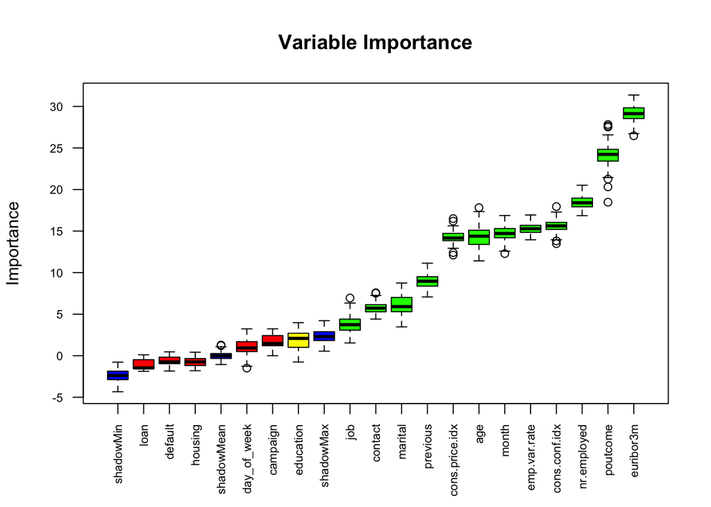

Next we will examine the distribution of the “yes” and “no” class across these significant variables.

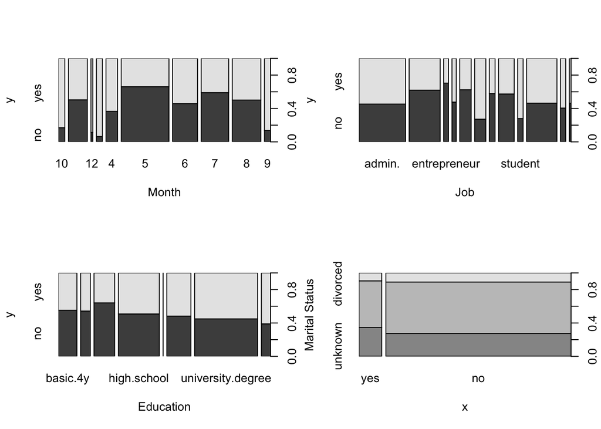

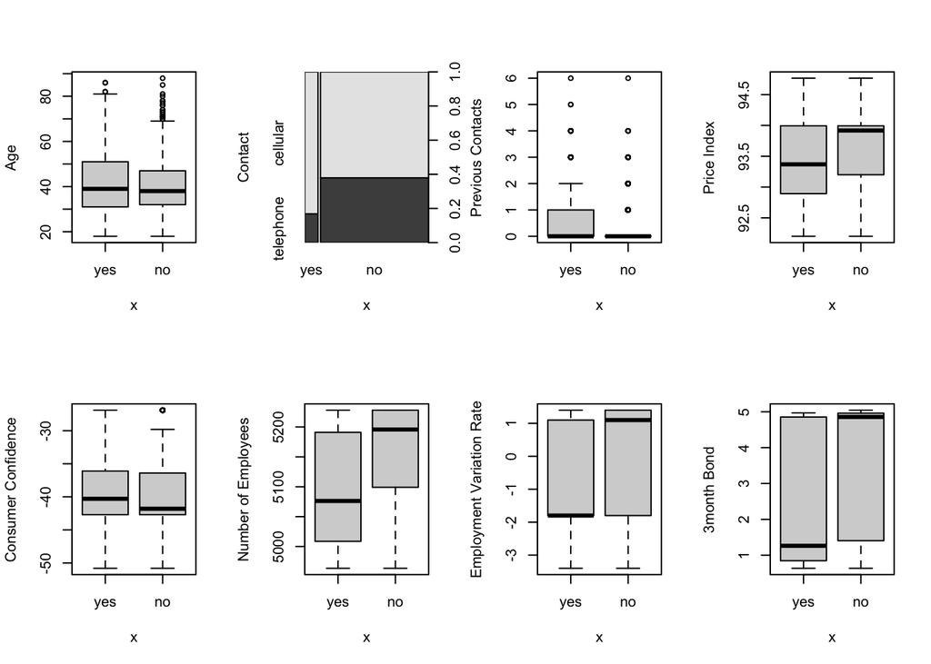

We can see that, perhaps surprisingly, the apparently strongest difference in means are in the aggregate economic indicators rather than the most of the individual personal data. This can potentially be a problem, because while the strength of the economic statistics as predictors can result in a more accurate model using training data, a prediction model that relies heavily on variables out of control of the bank is not useful to the bank when trying to decide who to call.

## VI - Findings

The confusion matrices and accuracy statistics from the models are listed below:

```
## [1] "Personal Logistic Regression"
##           Reference
## Prediction yes  no
##        yes  84 414
##        no   57 681
##    Pos Pred Value Balanced Accuracy
##         0.1686747         0.6088312
##
## [1] "Full Model Logistic Regression"
##           Reference
## Prediction yes  no
##        yes  74 151
##        no   67 944
##    Pos Pred Value Balanced Accuracy
##         0.3288889         0.6934616
##
## [1] "Personal Decision Tree"
##           Reference
## Prediction yes  no
##        yes 103 546
##        no   38 549
##    Pos Pred Value Balanced Accuracy
##         0.1587057         0.6159332
##
## [1] "Full Decision Tree"
##           Reference
## Prediction  yes   no
##        yes   61   84
##        no    80 1011
##    Pos Pred Value Balanced Accuracy
##         0.4206897         0.6779559
##
## [1] "Full Linear SVC"
##           Reference
## Prediction yes  no
##        yes  75 153
##        no   66 942
##    Pos Pred Value Balanced Accuracy
##         0.3289474         0.6960944
##
```

[output cut: 48 more lines]

```
## [1] "Linear SVC with sig Variables"
##           Reference
## Prediction yes  no
##        yes  76 154
##        no   65 941
##    Pos Pred Value Balanced Accuracy
##         0.3304348         0.6991839
##
## [1] "Linear Discriminant Analysis with sig Variables"
##           Reference
## Prediction yes  no
##        yes  76 149
##        no   65 946
##    Pos Pred Value Balanced Accuracy
##         0.3377778         0.7014670
```

Clearly the highest levels of both accuracy and rate of successful positive prediction are in the models that use the algorithmically selected variables, and so these models provide the best predictive performance when viewed at face value. However, the variable importance reveals the source of the high predictive value in the decision tree, SVC, and random forest is based on the quarterly economic indicators:

```
## [1] "Selected Decision Tree Variable Importance"
```

```
## rpart variable importance
##
##   only 20 most important variables shown (out of 33)
##
##                    Overall
## nr.employed         100.00
## euribor3m            89.58
## emp.var.rate         79.59
## poutcomesuccess      46.12
## previous             36.37
## cons.price.idx        0.00
## campaign              0.00
## month12               0.00
## age                   0.00
## cons.conf.idx         0.00
## `jobself-employed`    0.00
## jobtechnician         0.00
## month8                0.00
## jobmanagement         0.00
## maritalunknown        0.00
## maritalsingle         0.00
## jobhousemaid          0.00
## jobstudent            0.00
## jobunknown            0.00
## `jobblue-collar`      0.00
```

```
## [1] "Selected Random Forest Variable Importance"
```

```
## rf variable importance
##
##   only 20 most important variables shown (out of 33)
##
##                     Overall
## euribor3m           100.000
## age                  87.739
## nr.employed          66.540
## campaign             36.585
## cons.conf.idx        14.259
## emp.var.rate         13.328
## jobblue-collar       11.273
## jobtechnician        10.488
## maritalmarried        9.447
## maritalsingle         9.250
## poutcomesuccess       9.073
## cons.price.idx        8.935
## jobmanagement         7.533
## jobservices           6.296
## previous              5.640
## jobentrepreneur       4.301
## jobretired            4.254
## poutcomenonexistent   3.725
## jobunemployed         3.090
## jobhousemaid          2.650
```

```
## [1] "Selected Linear SVM Variable Importance"
```

```
## ROC curve variable importance
##
##                Importance
## nr.employed       100.000
## euribor3m          98.594
## emp.var.rate       80.075
## previous           48.272
## poutcome           27.002
## cons.price.idx     20.190
## campaign           16.221
## cons.conf.idx      14.992
## age                 8.286
## marital             7.750
## month               3.466
## job                 0.000
```

```
## [1] "Selected Linear Discriminant Analysis Importance"
```

[output not shown]

```
## [1] "Full Logistic Regression Variable Importance"
```

```
## glmnet variable importance
##
##   only 20 most important variables shown (out of 51)
##
##                     Overall
## educationilliterate 100.000
## month3               59.826
## poutcomesuccess      50.017
## defaultyes           40.115
## emp.var.rate         29.690
## contacttelephone     23.174
## jobmanagement        22.532
## jobself-employed     22.320
## maritalunknown       22.081
## housingunknown       21.747
## cons.price.idx       20.086
## month12              15.462
## jobentrepreneur      10.490
## month9               10.481
## poutcomenonexistent   9.965
## day_of_week4          9.514
## day_of_week2          9.208
## day_of_week5          8.610
## cons.conf.idx         8.417
## educationbasic.6y     8.145
```

The high importance value for the illiterate education category is not as concerning for the logistic model, because it represents only one observation in the original data set and thus is not relevant in any likely test or production data.

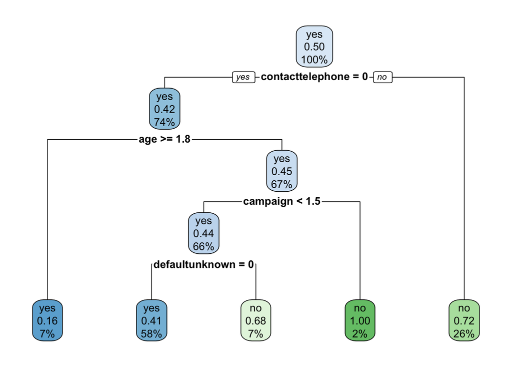

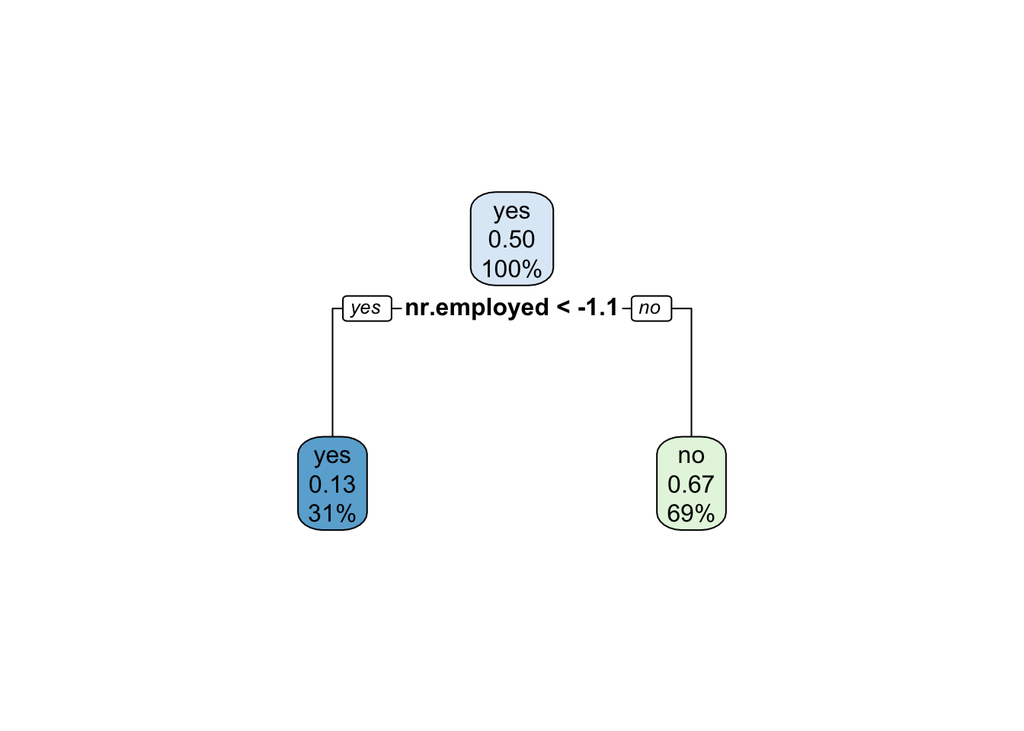

## VII - Conclusions

However there are potentially reasons to choose a less profitable model that predicts more positive calls overall. For example, if there were a minimum number of term deposits necessary to meet some regulatory requirement, the bank would need to prioritize reaching that minimum number at the expense of profitability on those calls. Or if the client-base for the bank is not large enough, they could eventually run out of people to call if their model is too conservative.

The full and algorithmically selected models of the random forest classifier achieve the highest levels of precision, however they are influenced heavily by the external predictors that leads to the issues described previously. The classifier that has the highest level of precision but without the skewed variable importance is the full model logistic regression. This classifier significantly outperforms the classifiers utilizing only the personal attributes and several of the more sophisticated models.

The chart below displays the range of cost ratios at which a given model will still provide profitable predictions, where the models with all the variables are “full”, the personalized attributes are “personal” and the algorithmically selected variables are “sig”.

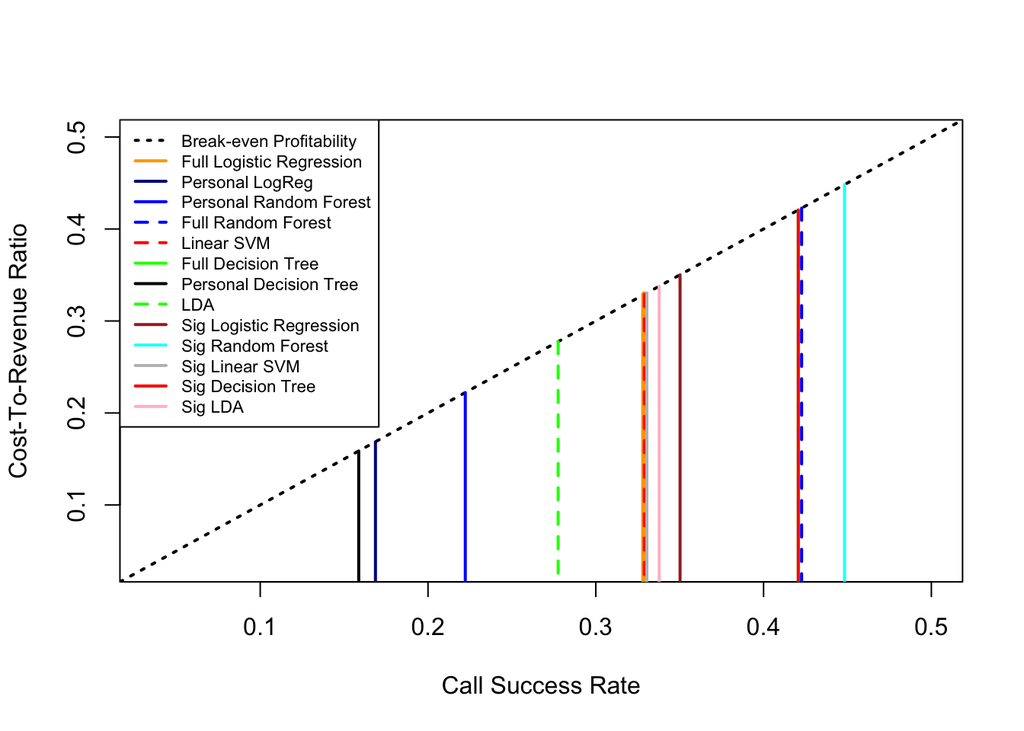

Overall, assuming the bank has the option to do so, the full logistic regression model provides the predictions that will accommodate the widest range of cost-to-revenue ratios without an excessive reliance on external variables.

## Appendix

#### Preprocessing the data

```r
set.seed(12345)
bank<-read.csv('bank-additional.csv',sep=";",stringsAsFactors = T)
sum(is.na(bank))
#duration in column 11
bank<-bank[-11]

#replace month abbreviations with numbers
monthord<-as.character(bank$month)
mn<-c('jan','feb','mar','apr','may','jun','jul',
  'aug','sep','oct','nov','dec')
md<-c(1,2,3,4,5,6,7,8,9,10,11,12)
monthord[monthord %in% mn] <- md[match(monthord, mn)]
bank$month<-as.factor(monthord)

#replace day of week abbreviations with numbers
weekord<-as.character(bank$day_of_week)
mn<-c('mon','tue','wed','thu','fri','sat','sun')
md<-c(1,2,3,4,5,6,7)
weekord[weekord %in% mn] <- md[match(weekord, mn)]
bank$day_of_week<-as.factor(weekord)

#reverse levels so "yes" is returned as the positive class to the caret model
bank$y <- factor(bank$y, levels=rev(levels(bank$y)))


#scale and remove variables with near-zero variance(which turns out to be pdays)

params<-preProcess(bank,method=c("scale","center","nzv"))
scaledbank<-predict(params,bank)

#separate the data into train and test sets

train<-sample(nrow(scaledbank),0.7*nrow(scaledbank))
banktrain<-scaledbank[train,]
banktest<-scaledbank[-train,]

#balance the target classes so the
banktrain<-upSample(x=banktrain[,-ncol(banktrain)],y=banktrain$y)
```

#### Determining most significant variables

```r
boruta_var_imp_output=Boruta(y~.,data=scaledbank,doTrace=1)

boruta_signif <- getSelectedAttributes(boruta_var_imp_output, withTentative = TRUE)



boruta_roug_fix_mod=TentativeRoughFix(boruta_var_imp_output)
# Variable Importance Scores
boruta_imps <- attStats(boruta_roug_fix_mod)
boruta_imps2 = boruta_imps[boruta_imps$decision != 'Rejected', c('meanImp', 'decision')]
boruta_imps2[order(-boruta_imps2$meanImp), ]


plot(boruta_var_imp_output, cex.axis=.7, las=2, xlab="", main="Variable Importance")
```

#### Training different models

```r
#TC <- trainControl(method = "boot", number=50,classProbs=TRUE,summaryFunction = twoClassSummary)
TC <- trainControl(method="repeatedcv", number=5,repeats=3,classProbs=TRUE,summaryFunction = twoClassSummary)


bankrf <- train(Class~age+marital+education+default+loan+contact+job+campaign+day_of_week+housing, data=banktrain,
                 method = "rf",
                 metric="ROC",
                 trControl = TC)

predrf<-predict(bankrf,banktest)

bankrffull <- train(Class~., data=banktrain,
                 method = "rf",
                 metric="ROC",
                 trControl = TC)

predrffull<-predict(bankrffull,banktest)



banktreefull=train(Class~.,data=banktrain, metric="Spec",trControl=TC,method='rpart',
               control = rpart.control(cp=0.0001, split=c("gini"),minbucket = 5))
predtreefull<-predict(banktreefull,banktest)


banktree=train(Class~age+marital+education+default+loan+contact+job+campaign+day_of_week+housing,data=banktrain, metric="Spec",trControl=TC,method='rpart',
               control = rpart.control(cp=0.0001, split=c("gini"),minbucket = 5))
predtree<-predict(banktree,banktest)


bankLOG <- train(Class~age+marital+education+default+loan+contact+job+campaign+day_of_week+housing, data=banktrain,
                 method = "glmnet",
                 metric="ROC",
                 trControl = TC)

predlog<-predict(bankLOG,banktest)


bankLOGfull <- train(Class~., data=banktrain,
                 method = "glmnet",
                 metric="ROC",
                 trControl = TC)

predlogfull<-predict(bankLOGfull,banktest)



TC <- trainControl(method="cv", number=5,repeats=3,
                   classProbs=TRUE,summaryFunction = twoClassSummary)

bankrad <- train(Class~., data=banktrain,
                 method = "svmLinear",
                 metric="ROC",
                 trControl = TC,
                 tuneGrid = expand.grid(C = seq(0.001, 0.1, length = 10)))


predrad<-predict(bankrad,banktest)


banklda <- train(Class~age+job+education+marital+month+day_of_week+previous+contact+campaign+cons.price.idx+cons.conf.idx+poutcome, data=banktrain,method = "lda",metric='ROC',trControl = trainControl(method = "cv",classProbs=TRUE))

predlda<-predict(banklda,banktest)

# SVM Model using Boruta Significant Variables
bankrad_bor <- train(Class~age+job+marital+month+previous+campaign+cons.price.idx+cons.conf.idx+poutcome+emp.var.rate+euribor3m+nr.employed, data=banktrain,
                 method = "svmLinear",
                 metric="ROC",
                 trControl = TC,
                 tuneLength=8)
predrad_bor<-predict(bankrad_bor,banktest)

# Linear Discriminant Analysis using Significant Variables
banklda_bor =train(Class~age+job+marital+month+previous+campaign+cons.price.idx+cons.conf.idx+poutcome+emp.var.rate+euribor3m+nr.employed, data=banktrain,method = "lda",metric='ROC',trControl = trainControl(method = "cv",classProbs=TRUE))

predlda_bor<-predict(banklda_bor,banktest)

# Random Forest using Significant Variables
bankrf_bor <- train(Class~age+job+marital+month+previous+campaign+cons.price.idx+cons.conf.idx+poutcome+emp.var.rate+euribor3m+nr.employed, data=banktrain,
                 method = "rf",
                 metric="ROC",
                 trControl = trainControl(method="repeatedcv", number=5,repeats = 3,classProbs=TRUE,summaryFunction = twoClassSummary))

predrf_bor<-predict(bankrf_bor,banktest)

# Logistic Regression using Significant Variables
bankLOG_bor <- train(Class~age+job+marital+month+previous+campaign+cons.price.idx+cons.conf.idx+poutcome+emp.var.rate+euribor3m+nr.employed, data=banktrain,
                 method = "glmnet",
                 metric="ROC",
                 trControl = trainControl(method="repeatedcv", number=5,repeats = 3,classProbs=TRUE,summaryFunction = twoClassSummary))
predlog_bor<-predict(bankLOG_bor,banktest)

# Decision Tree Using Significant Variabels

banktree_bor=train(Class~age+job+marital+month+previous+campaign+cons.price.idx+cons.conf.idx+poutcome+emp.var.rate+euribor3m+nr.employed,data=banktrain, metric="Spec",trControl=TC,method='rpart',
               control = rpart.control(cp=0.0001, split=c("gini"),minbucket = 5))
predtree_bor<-predict(banktree_bor,banktest)
```

#### Model output

```r
bankLOGfull
```

```
## glmnet
##
## 5146 samples
##   18 predictor
##    2 classes: 'yes', 'no'
##
## No pre-processing
## Resampling: Cross-Validated (5 fold, repeated 3 times)
## Summary of sample sizes: 4117, 4116, 4118, 4116, 4117, 4118, ...
## Resampling results across tuning parameters:
##
##   alpha  lambda        ROC        Sens       Spec
##   0.10   0.0004877916  0.8197845  0.6644570  0.8661705
##   0.10   0.0048779164  0.8186547  0.6594069  0.8637090
##   0.10   0.0487791645  0.8086173  0.6599287  0.8538622
##   0.55   0.0004877916  0.8199728  0.6618669  0.8663005
##   0.55   0.0048779164  0.8168297  0.6535779  0.8675935
##   0.55   0.0487791645  0.7942044  0.6564296  0.8523108
##   1.00   0.0004877916  0.8201544  0.6595353  0.8670774
##   1.00   0.0048779164  0.8130835  0.6520235  0.8685011
##   1.00   0.0487791645  0.7840336  0.6573294  0.8472567
##
## ROC was used to select the optimal model using the largest value.
## The final values used for the model were alpha = 1 and lambda = 0.0004877916.
```

```r
bankLOG_bor
```

```
## glmnet
##
## 5146 samples
##   12 predictor
##    2 classes: 'yes', 'no'
##
## No pre-processing
## Resampling: Cross-Validated (5 fold, repeated 3 times)
## Summary of sample sizes: 4116, 4116, 4118, 4117, 4117, 4118, ...
## Resampling results across tuning parameters:
##
##   alpha  lambda        ROC        Sens       Spec
##   0.10   0.0004877916  0.8111608  0.6505985  0.8753695
##   0.10   0.0048779164  0.8105235  0.6524123  0.8718711
##   0.10   0.0487791645  0.8044836  0.6552625  0.8628026
##   0.55   0.0004877916  0.8111147  0.6496909  0.8749809
##   0.55   0.0048779164  0.8091044  0.6547432  0.8718709
##   0.55   0.0487791645  0.7918267  0.6540979  0.8594346
##   1.00   0.0004877916  0.8109894  0.6502084  0.8745923
##   1.00   0.0048779164  0.8073871  0.6543551  0.8721298
##   1.00   0.0487791645  0.7847677  0.6588906  0.8469936
##
## ROC was used to select the optimal model using the largest value.
## The final values used for the model were alpha = 0.1 and lambda = 0.0004877916.
```

```r
banktree_bor
```

```
## CART
##
## 5146 samples
##   12 predictor
##    2 classes: 'yes', 'no'
##
## No pre-processing
## Resampling: Cross-Validated (5 fold)
## Summary of sample sizes: 4116, 4117, 4118, 4116, 4117
## Resampling results across tuning parameters:
##
##   cp          ROC        Sens       Spec
##   0.01748931  0.7636059  0.6393132  0.8694080
##   0.04275165  0.7458013  0.5926712  0.8857368
##   0.45783133  0.6320332  0.5099203  0.7541460
##
## Spec was used to select the optimal model using the largest value.
## The final value used for the model was cp = 0.04275165.
```

```r
bankrf_bor
```

```
## Random Forest
##
## 5146 samples
##   12 predictor
##    2 classes: 'yes', 'no'
##
## No pre-processing
## Resampling: Cross-Validated (5 fold, repeated 3 times)
## Summary of sample sizes: 4117, 4116, 4117, 4117, 4117, 4117, ...
## Resampling results across tuning parameters:
##
##   mtry  ROC        Sens       Spec
##    2    0.8645921  0.6605694  0.8823686
##   17    0.9979054  1.0000000  0.9166978
##   33    0.9972303  1.0000000  0.9148840
##
## ROC was used to select the optimal model using the largest value.
## The final value used for the model was mtry = 17.
```

```r
bankrad_bor
```

```
## Support Vector Machines with Linear Kernel
##
## 5146 samples
##   12 predictor
##    2 classes: 'yes', 'no'
##
## No pre-processing
## Resampling: Cross-Validated (5 fold)
## Summary of sample sizes: 4117, 4117, 4118, 4116, 4116
## Resampling results:
##
##   ROC        Sens       Spec
##   0.7860103  0.6533172  0.8666949
##
## Tuning parameter 'C' was held constant at a value of 1
```

```r
banklda_bor
```

```
## Linear Discriminant Analysis
##
## 5146 samples
##   12 predictor
##    2 classes: 'yes', 'no'
##
## No pre-processing
## Resampling: Cross-Validated (10 fold)
## Summary of sample sizes: 4632, 4632, 4631, 4630, 4632, 4631, ...
## Resampling results:
##
##   Accuracy   Kappa
##   0.7615574  0.5230997
```